# statistics

*solution_03_central_limit_theorem/02_normal/07_x_from_leftarea_v1*

First, draw a sketch. We can label the $C$ axis by adding integer multiples of 150 to 480. We know to shade the left because low values of $C$ satisfy the condition $C<c$ (regardless of the exact value of $c$). We don’t know exactly where to place the boundary, but we know the left area is 0.27.

It is helpful to know the following approximations:

| $z$ | $P(Z<z)$ |
| --- | --- |
| -3 | 0.001 |
| -2 | 0.023 |
| -1 | 0.159 |
| 0 | 0.5 |
| 1 | 0.841 |
| 2 | 0.977 |
| 3 | 0.999 |

So, we know the $z$-score is between -1 and 0. Remember, $Z$ and $z$ always refer to the **standard** normal variable.

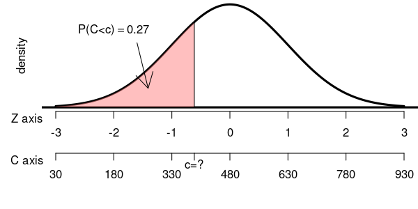

By using the $z$ table we can determine $z$ more precisely.

[output not shown]

Either -0.62 or -0.61 is a good estimation of $z$, and either value will lead you to an acceptable answer. Using other tools, a more accurate value can be found. I will show the work with a more accurate value.
$$z=-0.6128$$

We now convert the $z$ score into a $c$ score.
$$\begin{aligned}
c &= \mu+z\sigma \\
&= 480+(-0.6128)(150) \\
&= 388.1
\end{aligned}$$

We can also visualize this with a spinner.

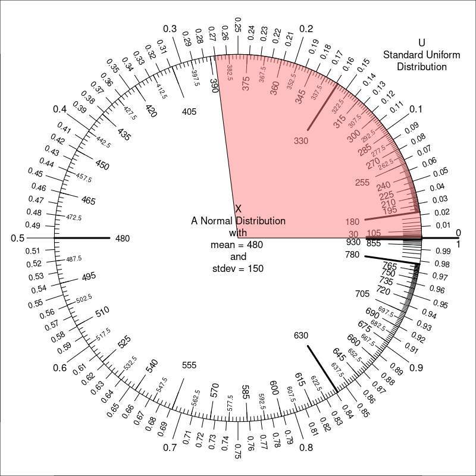

The tolerance for an acceptable answer was $\pm 10$ from 388.0780513. So, anything between 378.0780513 and 398.0780513 was accepted.